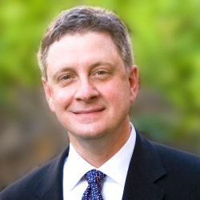

# Robert DelRossi

## Bio

I’m Robert DelRossi. I’ve a background in strategic planning, software development, and general business operations. I have worked in the financial services, retail software development, and in entertainment industries. My core ideology centers on deeply considered beliefs in authenticity, transparency, excellence of execution and continuous improvement.

Key among my business competencies are as a team-builder, performance-developer, communicator, and optimization-champion. As a technologist, my strengths include extensive knowledge of systems development processes, the development of sustainable architectures, solution evangelization, and in leveraging the value of data to optimize business performance.

Outside of work, I’m a rabid baseball fan, cook, want-to-be musician, and amateur bartender.

## Experience

**Gamblit Gaming, LLC** | Board Member | Audit Committee | Compensation Committee | August 2018 - present

**Crave / WhatsGood** | Advisor, Consumer Technology | June 2018 - October 2020

**Aristocrat Gaming** | Global Chief Technology Officer | General Manager Global Systems | Vice President R&D | January 2002 - February 2007

**TurboPower Software Company** | President | October 1997 - December 2001

## Education

**Boston University** | Boston, MA